# IODS course project

## Logistic regression and cross-validation

```r
date()
```

```
## [1] "Thu Dec 09 09:34:20 2021"
```

**FIRST, I created a new R Markdown file**, named it as ‘chapter3.Rmd’, and saved it to my IODS-project folder. Then, I included the new file as a child file in my ‘index.Rmd’ file.

**SECOND, I read the joined and modified ‘alc’ data into R from my local folder, and described it briefly.**

```r
library(readr)
setwd("C:/Users/ariv/Documents/IODS-project/IODS-project/data")
alc <- read_csv("alc.csv")
```

```
## * `` -> ...1
```

```r
View(alc)
```

```r
colnames(alc)[2:36]
```

```
##  [1] "school"     "sex"        "age"        "address"    "famsize"
##  [6] "Pstatus"    "Medu"       "Fedu"       "Mjob"       "Fjob"
## [11] "reason"     "guardian"   "traveltime" "studytime"  "schoolsup"
## [16] "famsup"     "activities" "nursery"    "higher"     "internet"
## [21] "romantic"   "famrel"     "freetime"   "goout"      "Dalc"
## [26] "Walc"       "health"     "failures"   "paid"       "absences"
## [31] "G1"         "G2"         "G3"         "alc_use"    "high_use"
```

The **alc** data set describes students of two Portuguese schools, their age, gender, socio-demographics, free-time including alcohol use, health status, etc. The data set consists of 370 students and 35 variables. Prof. **Paulo Cortez** (http://www3.dsi.uminho.pt/pcortez/Home.html) is the provider of the original data set (**Student Performance Data Set**, https://archive.ics.uci.edu/ml/datasets/Student+Performance).

**THIRD, I selected four potential explanatory variables for alcohol consumption** from the **alc** data set, explored them, and hypothesized their relationships with alcohol consumption.

*This corresponds to the data analysis part of Exercise 3, its 3. and 4. tasks.*

The first potential explanatory variable for alcohol consumption was **sex**, as, in general, there are gender differences in alcohol consumption (Wilsnack et al. 2000 https://onlinelibrary.wiley.com/doi/abs/10.1046/j.1360-0443.2000.95225112.x). I hypothesized that males consume more alcohol and are more often heavy drinkers than females.

```r
library(dplyr); library(ggplot2); library(readr)
setwd("C:/Users/ariv/Documents/IODS-project/IODS-project/data")
alc <- read_csv("alc.csv")
```

```
## * `` -> ...1
```

```r
alc %>% group_by(sex, high_use) %>% count
```

```
## # A tibble: 4 x 3
## # Groups:   sex, high_use [4]
##   sex   high_use     n
##   <chr> <lgl>    <int>
## 1 F     FALSE      154
## 2 F     TRUE        41
## 3 M     FALSE      105
## 4 M     TRUE        70
```

The number of males in the **alc** data is 175, and that of females is 195. Of the 175 males, 70 i.e. 41% are heavy drinkers, whereas of the 195 females only 41 i.e. 21% are heavy drinkers, which appears to support the hypothesis.

The second potential explanatory variable for alcohol consumption was **age**. I expected that the proportion of heavy drinkers increases together with age.

```r
alc %>% group_by(high_use) %>% summarise(count = n(), mean_age = mean(age))
```

```
## # A tibble: 2 x 3
##   high_use count mean_age
##   <lgl>    <int>    <dbl>
## 1 FALSE      259     16.5
## 2 TRUE       111     16.8
```

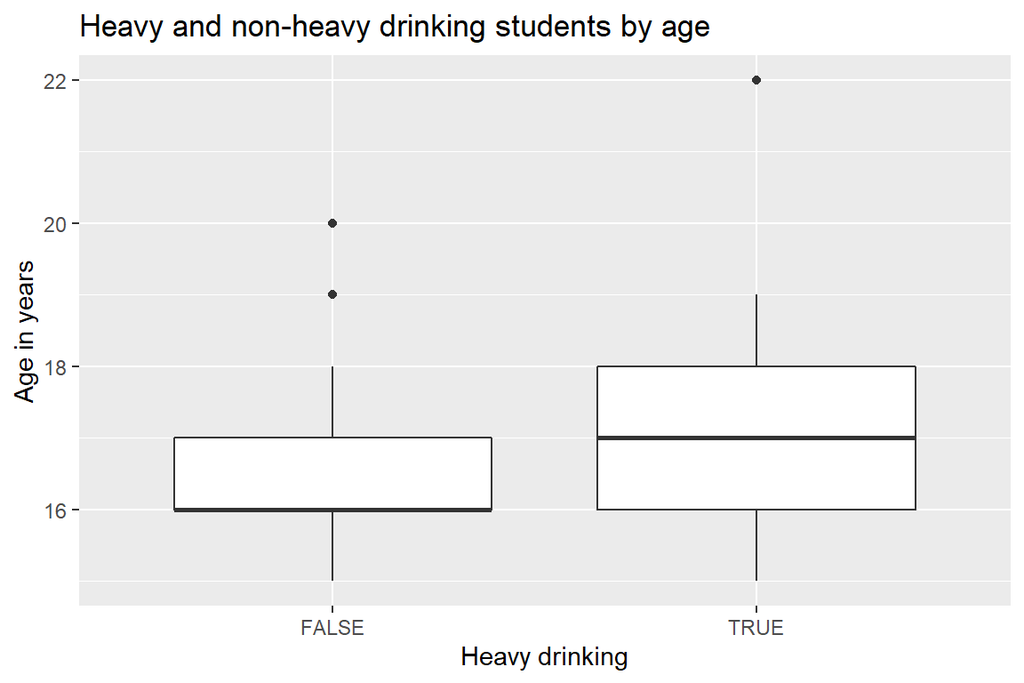

```r
g1 <- ggplot(alc, aes(x = high_use, y = age))
g1 + geom_boxplot() + xlab("Heavy drinking") + ylab("Age in years") + ggtitle("Heavy and non-heavy drinking students by age")
```

The mean age of heavy drinking students was 16.8 years and that of non-heavy drinking students was 16.5 years. Based on the box plot the median age of heavy-drinking students was 17 years and that of non-heavy drinking students was 16 years. Thus, the age distribution slightly suggested that heavy-drinking students are older.

The third potential explanatory variable for alcohol consumption was **goout** that indicates going out with friends as a numeric values from 1 (very low frequency) to 5 (very high frequency). By and large, friends’ drinking behavior is related to adolescents’ drinking (Bot et al. 2005 https://www.sciencedirect.com/science/article/pii/S0306460304003314) and, consequently, I expected going out with friends associates with heavy-drinking also in the *alc* data.

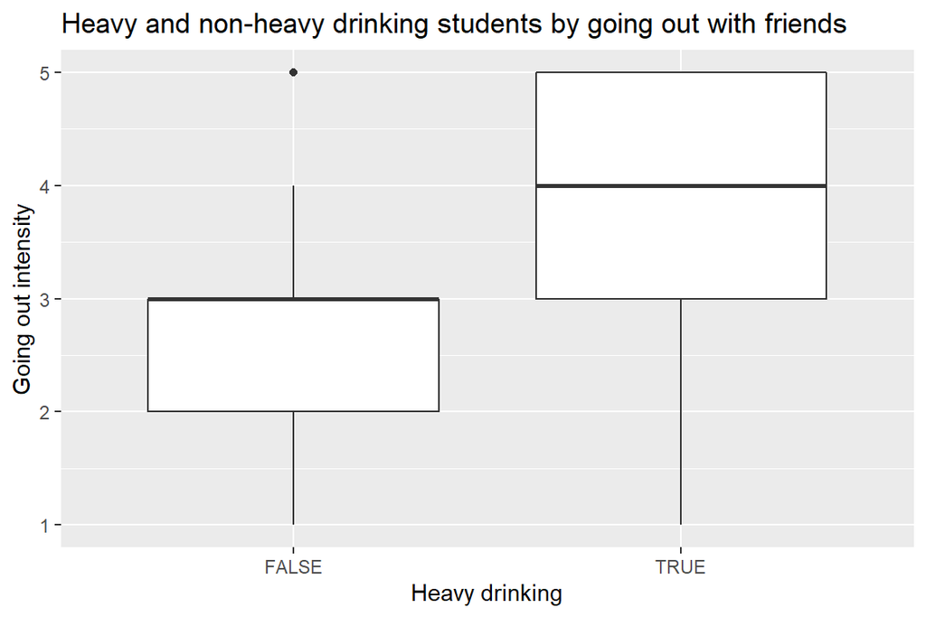

```r
g2 <- ggplot(alc, aes(x = high_use, y = goout))
g2 + geom_boxplot() + xlab("Heavy drinking") + ylab("Going out intensity") + ggtitle("Heavy and non-heavy drinking students by going out with friends")
```

The distribution of the **goout** variable suggested that heavy drinking students go out with friends more frequently and/or with higher intensity than non-heavy drinking students. This supports my hypothesis.

The fourth potential explanatory variable for alcohol consumption was **address** that indicates living in an urban (U) or rural area (R). I chose this variable because in some European countries, such as Germany, adolescents living in rural areas appear to be more susceptible to drinking problems (Donath et al. 2011 https://bmcpublichealth.biomedcentral.com/articles/10.1186/1471-2458-11-84).

```r
alc %>% group_by(address, high_use) %>% count
```

```
## # A tibble: 4 x 3
## # Groups:   address, high_use [4]
##   address high_use     n
##   <chr>   <lgl>    <int>
## 1 R       FALSE       50
## 2 R       TRUE        31
## 3 U       FALSE      209
## 4 U       TRUE        80
```

In the **alc** data, the number of students living in rural areas was 81 and that of students living in urban areas was 289. Of the 81 ‘rural students’, 31 i.e. 38% was heavy drinkers, whereas of the 289 ‘urban students’ only 28% were heavy drinkers. This supports my hypothesis that living in a rural area predispose students to drinking problems.

**FOURTH, I performed logistic regression** to explore the relationship between the four selected explanatory variables (**sex, age, goout, address**) and alcohol consumption. As a target variables, I used the binary **high_use** variable.

```r
m <- glm(high_use ~ sex + age + goout + address, data = alc, family = "binomial")
summary(m)
```

```
##
## Call:
## glm(formula = high_use ~ sex + age + goout + address, family = "binomial",
##     data = alc)
##
## Deviance Residuals:
##     Min       1Q   Median       3Q      Max
## -1.8228  -0.8299  -0.5691   0.8642   2.5757
##
## Coefficients:
##             Estimate Std. Error z value Pr(>|z|)
## (Intercept) -4.51281    1.86714  -2.417 0.015651 *
## sexM         0.91960    0.25301   3.635 0.000278 ***
## age          0.06998    0.10882   0.643 0.520165
## goout        0.77084    0.12193   6.322 2.59e-10 ***
## addressU    -0.65798    0.30375  -2.166 0.030296 *
## ---
## Signif. codes:  0 '***' 0.001 '**' 0.01 '*' 0.05 '.' 0.1 ' ' 1
##
## (Dispersion parameter for binomial family taken to be 1)
##
##     Null deviance: 452.04  on 369  degrees of freedom
## Residual deviance: 383.16  on 365  degrees of freedom
## AIC: 393.16
##
## Number of Fisher Scoring iterations: 4
```

```r
coef(m)
```

```
## (Intercept)        sexM         age       goout    addressU
## -4.51281362  0.91959734  0.06997835  0.77084332 -0.65798307
```

```r
OR <- coef(m) %>% exp
CI <- confint(m) %>% exp
cbind(OR, CI)
```

```
##                     OR        2.5 %    97.5 %
## (Intercept) 0.01096756 0.0002635969 0.4070390
## sexM        2.50828021 1.5350500632 4.1473172
## age         1.07248496 0.8667064226 1.3294502
## goout       2.16158839 1.7130240865 2.7658611
## addressU    0.51789484 0.2850459734 0.9412459
```

Based on the logistic regression model with **sex**, **age**, **goout**, and **address** as explanatory variables, male gender, going out with friends, and living in a rural area increased the odds of being a heavy drinker. The odds of **men** was 2.5-times the odds of women (OR, 95% CI: 2.51, 1.54-4.15). One point increase in the **going out** scale increased the odds by 2.2 (OR, 95% CI: 2.16, 1.71-2.77). The odds of students living in an **urban** area was 0.5-times the odds of students living in a rural area (OR, 95% CI: 0.52, 0.29-0.94). With respect to age, the 95% CI for the OR contained 1, which denotes that age had no statistically significant effect on the OR. The result supported my hypotheses except for age.

**FIFTH, I explored the predictive power of the model.**

```r
m <- glm(high_use ~ sex + age + goout + address, data = alc, family = "binomial")
probabilities <- predict(m, type = "response")
alc <- mutate(alc, probability = probabilities)
alc <- mutate(alc, prediction = probability >0.5)
select(alc, sex, age, goout, address, high_use, probability, prediction) %>% tail(10)
```

```
## # A tibble: 10 x 7
##    sex     age goout address high_use probability prediction
##    <chr> <dbl> <dbl> <chr>   <lgl>          <dbl> <lgl>
##  1 M        17     3 U       FALSE         0.321  FALSE
##  2 M        19     2 R       FALSE         0.327  FALSE
##  3 M        18     3 R       TRUE          0.495  FALSE
##  4 F        18     3 R       FALSE         0.281  FALSE
##  5 F        18     3 R       FALSE         0.281  FALSE
##  6 F        19     2 R       FALSE         0.162  FALSE
##  7 F        18     4 U       FALSE         0.304  FALSE
##  8 F        18     1 U       FALSE         0.0415 FALSE
##  9 M        17     5 U       TRUE          0.688  TRUE
## 10 M        18     1 R       TRUE          0.173  FALSE
```

```r
table(high_use = alc$high_use, prediction = alc$prediction)
```

```
##         prediction
## high_use FALSE TRUE
##    FALSE   243   16
##    TRUE     65   46
```

The **training error** of the model i.e. the total proportion on inaccurately classified individuals was (16+65)/(243+16+65+46)*100 = 21.9%. The model was better in predicting non-heavy drinking students. Of the 111 heavy-drinkers the model ‘correctly recognized’ only 46 (41%), whereas of the 259 non-heavy drinkers the model ‘correctly recognized’ 243 (94%).

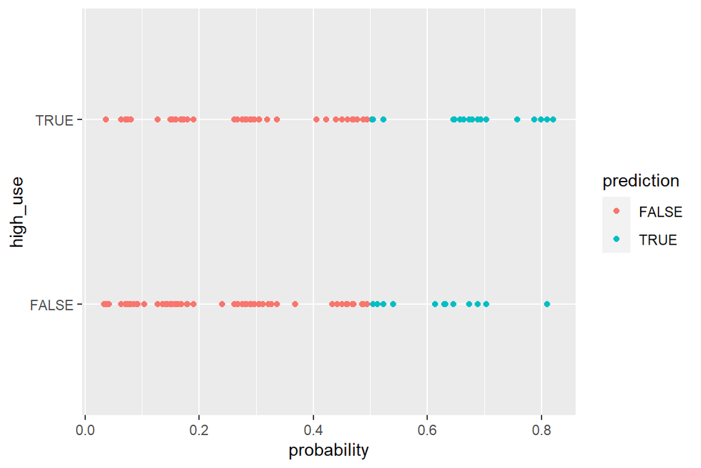

```r
library(dplyr); library(ggplot2)
g <- ggplot(alc, aes(x = probability, y = high_use, col = prediction))
g + geom_point()
```

```r
table(high_use = alc$high_use, prediction = alc$prediction) %>% prop.table %>% addmargins
```

```
##         prediction
## high_use      FALSE       TRUE        Sum
##    FALSE 0.65675676 0.04324324 0.70000000
##    TRUE  0.17567568 0.12432432 0.30000000
##    Sum   0.83243243 0.16756757 1.00000000
```

To compare the model performance to guessing I created a **guesspred** variable based on random numbers.

```r
alc$guessprop <- runif(370)
alc$guesspred <- ifelse(alc$guessprop > 0.5, "TRUE","FALSE")
table(high_use = alc$high_use, prediction = alc$guesspred)
```

```
##         prediction
## high_use FALSE TRUE
##    FALSE   128  131
##    TRUE     57   54
```

```r
table(high_use = alc$high_use, prediction = alc$guesspred) %>% prop.table %>% addmargins
```

```
##         prediction
## high_use     FALSE      TRUE       Sum
##    FALSE 0.3459459 0.3540541 0.7000000
##    TRUE  0.1540541 0.1459459 0.3000000
##    Sum   0.5000000 0.5000000 1.0000000
```

**SIXTH, I carried out the BONUS task and performed 10-fold cross-validation on my model.**

```r
loss_func <- function(class, prob) {
  n_wrong <- abs(class - prob) > 0.5
  mean(n_wrong)
}
loss_func(class = alc$high_use, prob = alc$probability)
```

```
## [1] 0.2189189
```

```r
library(boot)
cv <- cv.glm(data = alc, cost = loss_func, glmfit = m, K = 10)
cv$delta[1]
```

```
## [1] 0.2459459
```

OBS! I did not carried out the SUPER-BONUS task.